# Human Activity Recognition

Kieran Harding

03/03/2019

# Summary

The Weight Lifting Exercises dataset (WLE) was prepared to test recognition of how well a given exercise (Unilateral Dumbbell Biceps Curl) using data from sensors on the subject’s body. This report attempts to use the sensor data to identify which classe each repetition falls under (correctly performed, or one of 4 common mistakes).

Of the methods tested, Random Forests was found to perform the best, though boosted trees follows closely. By adjusting the Random Forest parameter to use 4 random variables per tree, we were able to correctly predict all 20 of the test cases.

Further improvement may be possible by increasing the tree count and by investigating (and eliminating, if warranted) some outlier values in the training dataset that could represent errors in data collection.

# Explore the data

```r
dim(df.train)
```

```
## [1] 19622   160
```

```r
summary(df.train)
```

See the appendix for the output of the summary call, but it has 19622 rows, with plenty of columns not populating them very well. There seems to be a pattern of columns missing 19216 items, and several have `#DIV/0` errors as well.

This is enough to make the column useless, so we will just get rid of them.

What about variable classes?

```r
str(df.train)
```

Again, output is in the appendix. What we learn is that everything with an error has become a factor variable, which may complicate filtering them a bit. Luckily, it looks like every column with errors also has the 19216 blank values so they will get filtered that way.

Also drop a few columns that serve as de facto row identifiers and will mess with results.

```r
df.train <- df.train %>%
    # 2000 chosen arbitrarily as ~10% of variables
    select_if(~sum(is.na(.)) < 2000 & sum(. == "") < 2000) %>%
    # Remove the variables that allow identifying rows
    select(-X, -contains("timestamp"), -new_window, -num_window)

# dim(df.train)
```

This isn’t a dealbreaker right now, but it’s worth remembering in case later results are strange.

# Feature Reduction

Running through some of the models the first time puts a strain on my computer, to the point that it doesn’t always finish without running out of memory. Here are a couple of options to reduce.

## findCorrelation

`findCorrelation` returns a list of columns to remove to reduce correlation. A lower cutoff value will be more aggressive.

```r
cutoff <- 0.75
cor(select(df.train, -classe, -user_name)) %>%
    findCorrelation(cutoff=cutoff, names=T)
```

```
##  [1] "accel_belt_z"      "roll_belt"         "accel_belt_y"
##  [4] "accel_arm_y"       "total_accel_belt"  "accel_dumbbell_z"
##  [7] "accel_belt_x"      "pitch_belt"        "magnet_dumbbell_x"
## [10] "accel_dumbbell_y"  "magnet_dumbbell_y" "accel_arm_x"
## [13] "accel_dumbbell_x"  "accel_arm_z"       "magnet_arm_y"
## [16] "magnet_belt_z"     "accel_forearm_y"   "gyros_forearm_y"
## [19] "gyros_dumbbell_x"  "gyros_dumbbell_z"  "gyros_arm_x"
```

## varImp by Tree model

Strictly speaking model building comes later, but use a tree model for variable importance.

```r
set.seed(1984)
tree <- train(classe ~ ., data = df.train, method = "rpart")
imp <- varImp(tree)$importance
imp$var <- row.names(imp)
imp <- imp %>%
    filter(Overall > 0) %>%
    arrange(-Overall)

feature.cols <- imp$var
feature.cols
```

```
##  [1] "pitch_forearm"     "roll_forearm"      "roll_belt"
##  [4] "magnet_dumbbell_y" "accel_belt_z"      "magnet_belt_y"
##  [7] "yaw_belt"          "magnet_dumbbell_z" "total_accel_belt"
## [10] "magnet_arm_x"      "accel_arm_x"       "roll_dumbbell"
## [13] "accel_dumbbell_y"  "roll_arm"
```

There is some overlap between the methods. We will use the model-based version since I expect it to be better at identfying complex relationships than the correlation model.

# Models

We will used cross-validation to compare the models. 10 folds should be good to strike a balance between bias reduction and not straining my computer (or patience).

Now we can compare these methods by confusion matrices.

### Decision Tree

```
## Cross-Validated (10 fold) Confusion Matrix
##
## (entries are percentual average cell counts across resamples)
##
##           Reference
## Prediction    A    B    C    D    E
##          A 25.9  8.0  8.1  7.4  2.7
##          B  0.4  6.6  0.6  2.9  2.5
##          C  1.7  3.4  8.1  4.3  3.6
##          D  0.3  1.3  0.7  1.8  1.4
##          E  0.1  0.0  0.0  0.0  8.3
##
##  Accuracy (average) : 0.5065
```

### Random Forest

```
## Cross-Validated (10 fold) Confusion Matrix
##
## (entries are percentual average cell counts across resamples)
##
##           Reference
## Prediction    A    B    C    D    E
##          A 28.4  0.1  0.0  0.0  0.0
##          B  0.0 19.1  0.1  0.0  0.0
##          C  0.0  0.1 17.3  0.2  0.0
##          D  0.0  0.0  0.0 16.1  0.1
##          E  0.0  0.0  0.0  0.0 18.3
##
##  Accuracy (average) : 0.9913
```

### Gradient Boosting Machine (boosted tree)

```
## Cross-Validated (10 fold) Confusion Matrix
##
## (entries are percentual average cell counts across resamples)
##
##           Reference
## Prediction    A    B    C    D    E
##          A 27.7  0.8  0.1  0.1  0.0
##          B  0.4 17.3  0.7  0.2  0.2
##          C  0.2  1.0 16.0  0.8  0.3
##          D  0.1  0.3  0.7 15.3  0.3
##          E  0.0  0.0  0.0  0.1 17.6
##
##  Accuracy (average) : 0.939
```

### Linear Discriminant Analysis

```
## Cross-Validated (10 fold) Confusion Matrix
##
## (entries are percentual average cell counts across resamples)
##
##           Reference
## Prediction    A    B    C    D    E
##          A 19.9  4.8  5.2  2.1  2.2
##          B  3.0  8.6  2.0  2.8  3.1
##          C  2.0  3.0  9.1  1.3  2.7
##          D  3.1  1.9  0.8  8.8  2.5
##          E  0.4  1.0  0.4  1.3  7.9
##
##  Accuracy (average) : 0.5421
```

Random forest is the clear best bet, but can we improve it?

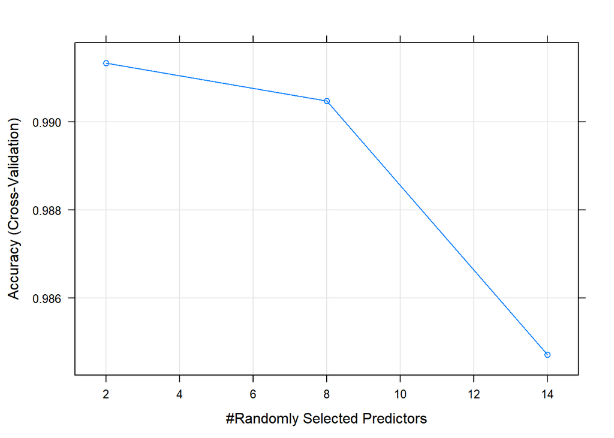

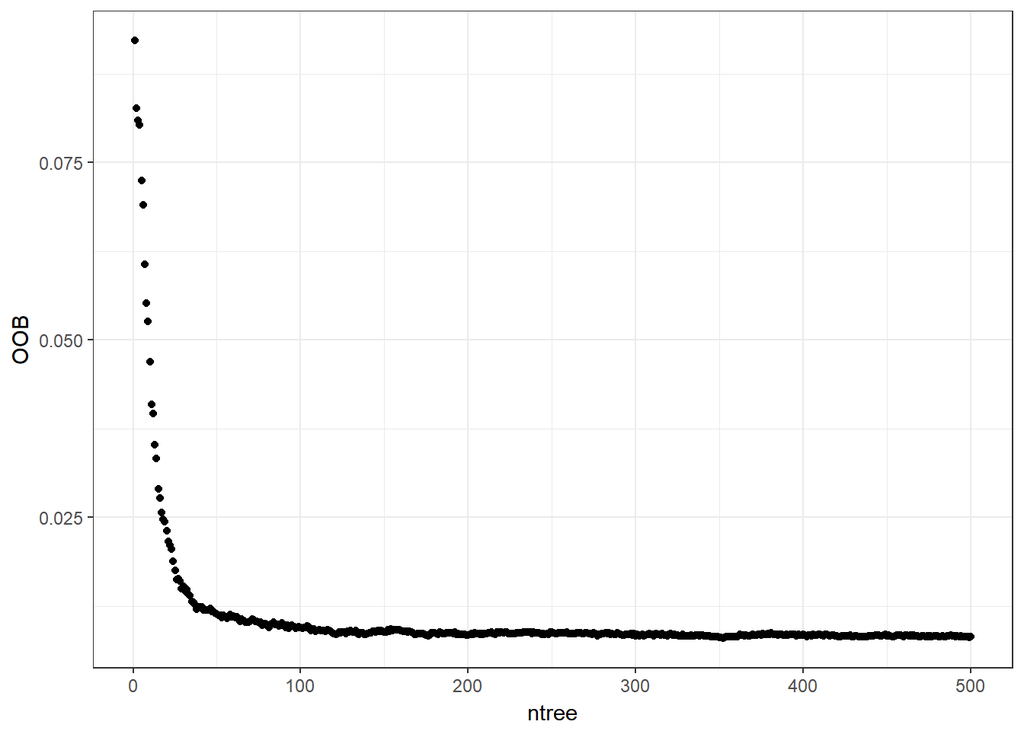

The out-of-bag error seems to be mostly stabilized around 100 trees, but does still continue to improve slightly. We will leave it as-is, and increase later if we need it.

So 2 is the best of our tried `mtry` values (2, 8, 14), and there is maybe a trend of improvement as they decrease. We will test 1 and a few in the high end range between 2 and 8.

# Final Model

```r
grid <- expand.grid(mtry = c(1, 2, 4, 6))

rf2 <- train(x = select(df.train.filtered, -classe),
             y = df.train.filtered$classe,
             method = "rf", trControl = control,
             tuneGrid = grid)
```

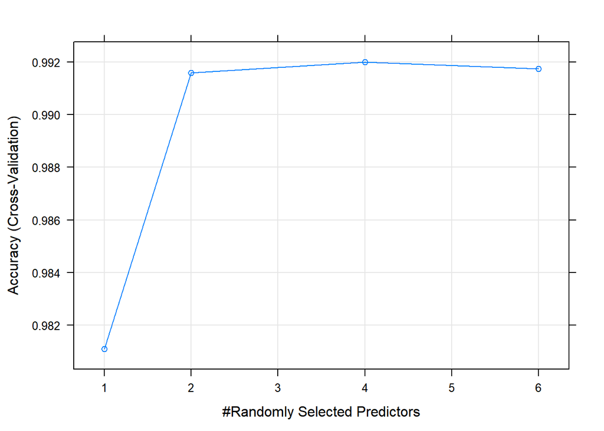

```
## Random Forest
##
## 19622 samples
##    14 predictor
##     5 classes: 'A', 'B', 'C', 'D', 'E'
##
## No pre-processing
## Resampling: Cross-Validated (10 fold)
## Summary of sample sizes: 17659, 17659, 17659, 17660, 17660, 17661, ...
## Resampling results across tuning parameters:
##
##   mtry  Accuracy   Kappa
##   1     0.9810932  0.9760788
##   2     0.9915915  0.9893633
##   4     0.9919993  0.9898794
##   6     0.9917445  0.9895575
##
## Accuracy was used to select the optimal model using the largest value.
## The final value used for the model was mtry = 4.
```

# Appendix

### Long outputs

```r
summary(df.train)
```

```
##     user_name      roll_belt        pitch_belt          yaw_belt
##  adelmo  :3892   Min.   :-28.90   Min.   :-55.8000   Min.   :-180.00
##  carlitos:3112   1st Qu.:  1.10   1st Qu.:  1.7600   1st Qu.: -88.30
##  charles :3536   Median :113.00   Median :  5.2800   Median : -13.00
##  eurico  :3070   Mean   : 64.41   Mean   :  0.3053   Mean   : -11.21
##  jeremy  :3402   3rd Qu.:123.00   3rd Qu.: 14.9000   3rd Qu.:  12.90
##  pedro   :2610   Max.   :162.00   Max.   : 60.3000   Max.   : 179.00
##  total_accel_belt  gyros_belt_x        gyros_belt_y       gyros_belt_z
##  Min.   : 0.00    Min.   :-1.040000   Min.   :-0.64000   Min.   :-1.4600
##  1st Qu.: 3.00    1st Qu.:-0.030000   1st Qu.: 0.00000   1st Qu.:-0.2000
##  Median :17.00    Median : 0.030000   Median : 0.02000   Median :-0.1000
##  Mean   :11.31    Mean   :-0.005592   Mean   : 0.03959   Mean   :-0.1305
##  3rd Qu.:18.00    3rd Qu.: 0.110000   3rd Qu.: 0.11000   3rd Qu.:-0.0200
##  Max.   :29.00    Max.   : 2.220000   Max.   : 0.64000   Max.   : 1.6200
##   accel_belt_x       accel_belt_y     accel_belt_z     magnet_belt_x
##  Min.   :-120.000   Min.   :-69.00   Min.   :-275.00   Min.   :-52.0
##  1st Qu.: -21.000   1st Qu.:  3.00   1st Qu.:-162.00   1st Qu.:  9.0
##  Median : -15.000   Median : 35.00   Median :-152.00   Median : 35.0
##  Mean   :  -5.595   Mean   : 30.15   Mean   : -72.59   Mean   : 55.6
##  3rd Qu.:  -5.000   3rd Qu.: 61.00   3rd Qu.:  27.00   3rd Qu.: 59.0
##  Max.   :  85.000   Max.   :164.00   Max.   : 105.00   Max.   :485.0
##  magnet_belt_y   magnet_belt_z       roll_arm         pitch_arm
##  Min.   :354.0   Min.   :-623.0   Min.   :-180.00   Min.   :-88.800
##  1st Qu.:581.0   1st Qu.:-375.0   1st Qu.: -31.77   1st Qu.:-25.900
##  Median :601.0   Median :-320.0   Median :   0.00   Median :  0.000
##  Mean   :593.7   Mean   :-345.5   Mean   :  17.83   Mean   : -4.612
##  3rd Qu.:610.0   3rd Qu.:-306.0   3rd Qu.:  77.30   3rd Qu.: 11.200
##  Max.   :673.0   Max.   : 293.0   Max.   : 180.00   Max.   : 88.500
##     yaw_arm          total_accel_arm  gyros_arm_x        gyros_arm_y
##  Min.   :-180.0000   Min.   : 1.00   Min.   :-6.37000   Min.   :-3.4400
##  1st Qu.: -43.1000   1st Qu.:17.00   1st Qu.:-1.33000   1st Qu.:-0.8000
##  Median :   0.0000   Median :27.00   Median : 0.08000   Median :-0.2400
##  Mean   :  -0.6188   Mean   :25.51   Mean   : 0.04277   Mean   :-0.2571
##  3rd Qu.:  45.8750   3rd Qu.:33.00   3rd Qu.: 1.57000   3rd Qu.: 0.1400
##  Max.   : 180.0000   Max.   :66.00   Max.   : 4.87000   Max.   : 2.8400
##   gyros_arm_z       accel_arm_x       accel_arm_y      accel_arm_z
##  Min.   :-2.3300   Min.   :-404.00   Min.   :-318.0   Min.   :-636.00
##  1st Qu.:-0.0700   1st Qu.:-242.00   1st Qu.: -54.0   1st Qu.:-143.00
##  Median : 0.2300   Median : -44.00   Median :  14.0   Median : -47.00
##  Mean   : 0.2695   Mean   : -60.24   Mean   :  32.6   Mean   : -71.25
```

[output cut: 50 more lines]

```
##  Max.   :311.00000   Max.   :231.0000   Max.   : 477.00   Max.   : 923.0
##  accel_forearm_z   magnet_forearm_x  magnet_forearm_y magnet_forearm_z
##  Min.   :-446.00   Min.   :-1280.0   Min.   :-896.0   Min.   :-973.0
##  1st Qu.:-182.00   1st Qu.: -616.0   1st Qu.:   2.0   1st Qu.: 191.0
##  Median : -39.00   Median : -378.0   Median : 591.0   Median : 511.0
##  Mean   : -55.29   Mean   : -312.6   Mean   : 380.1   Mean   : 393.6
##  3rd Qu.:  26.00   3rd Qu.:  -73.0   3rd Qu.: 737.0   3rd Qu.: 653.0
##  Max.   : 291.00   Max.   :  672.0   Max.   :1480.0   Max.   :1090.0
##  classe
##  A:5580
##  B:3797
##  C:3422
##  D:3216
##  E:3607
##
```

```r
str(df.train)
```

```
## 'data.frame':    19622 obs. of  54 variables:
##  $ user_name           : Factor w/ 6 levels "adelmo","carlitos",..: 2 2 2 2 2 2 2 2 2 2 ...
##  $ roll_belt           : num  1.41 1.41 1.42 1.48 1.48 1.45 1.42 1.42 1.43 1.45 ...
##  $ pitch_belt          : num  8.07 8.07 8.07 8.05 8.07 8.06 8.09 8.13 8.16 8.17 ...
##  $ yaw_belt            : num  -94.4 -94.4 -94.4 -94.4 -94.4 -94.4 -94.4 -94.4 -94.4 -94.4 ...
##  $ total_accel_belt    : int  3 3 3 3 3 3 3 3 3 3 ...
##  $ gyros_belt_x        : num  0 0.02 0 0.02 0.02 0.02 0.02 0.02 0.02 0.03 ...
##  $ gyros_belt_y        : num  0 0 0 0 0.02 0 0 0 0 0 ...
##  $ gyros_belt_z        : num  -0.02 -0.02 -0.02 -0.03 -0.02 -0.02 -0.02 -0.02 -0.02 0 ...
##  $ accel_belt_x        : int  -21 -22 -20 -22 -21 -21 -22 -22 -20 -21 ...
##  $ accel_belt_y        : int  4 4 5 3 2 4 3 4 2 4 ...
##  $ accel_belt_z        : int  22 22 23 21 24 21 21 21 24 22 ...
##  $ magnet_belt_x       : int  -3 -7 -2 -6 -6 0 -4 -2 1 -3 ...
##  $ magnet_belt_y       : int  599 608 600 604 600 603 599 603 602 609 ...
##  $ magnet_belt_z       : int  -313 -311 -305 -310 -302 -312 -311 -313 -312 -308 ...
```

[output cut: 40 more lines]

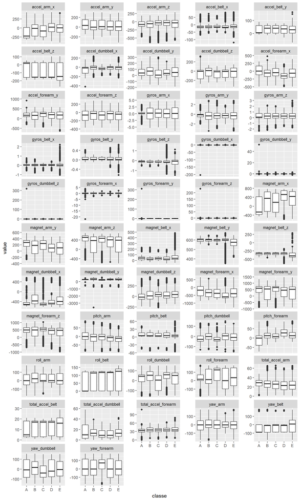

```r
df.train %>%
    select(-user_name) %>%
    gather(key = key, value = value, -classe) %>%
    ggplot(aes(classe, value)) + geom_boxplot() +
    facet_wrap(~ key, scales = "free_y", ncol=5)
```